# R Notebook

#### TM diversity

##### raw diversity

```
 1-1  1-3 10-1 10-3 10-5 11-1 11-3 11-5 12-1 12-3 12-5 13-1 13-5
 469  372   53  104   79  144  134  212  122  353  565   74   88
14-1 14-5 15-1 15-5 16-1 16-5 17-1 17-5 18-1 18-5 19-1 19-5  2-1
 402  407   73   77   86   79  236  271  198  373   82   80  180
 2-3  2-5 20-1 20-5 21-1 22-5 23-1 23-5  3-1  3-3  3-5  5-1  5-3
 143  145  138    9   28   53    1   84   28   21   28   91  270
 5-5  6-1  6-3  6-5  7-1  7-3  7-5  8-1  8-3  8-5  9-1  9-3  9-5
 377  327  286  124   35   45   18   23   14    9  210   52  127
```

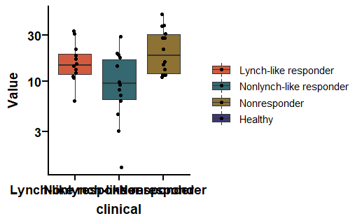

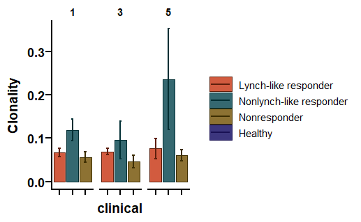

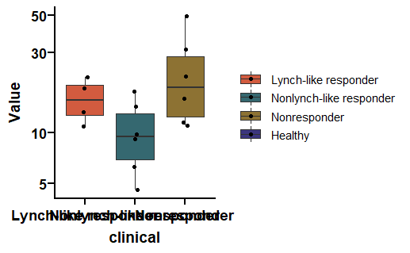

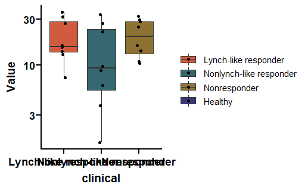

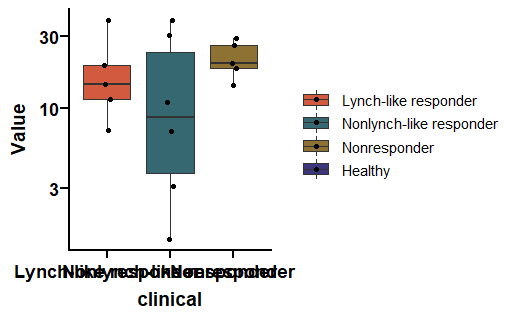

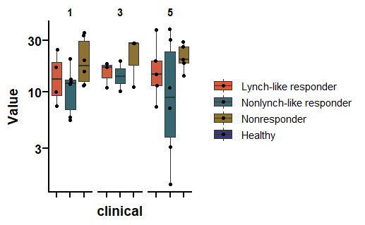

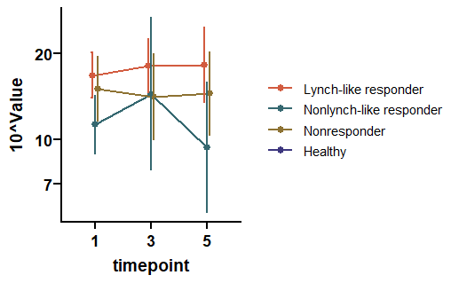

##### Change in diversity

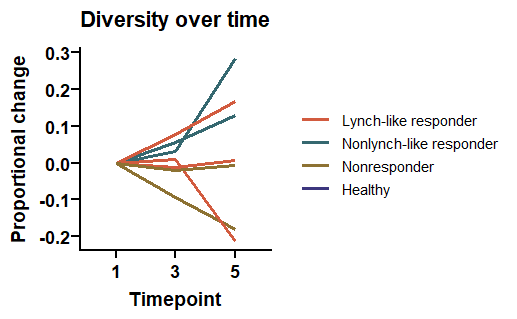

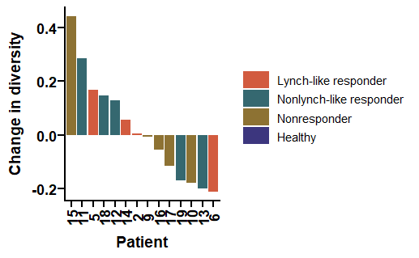

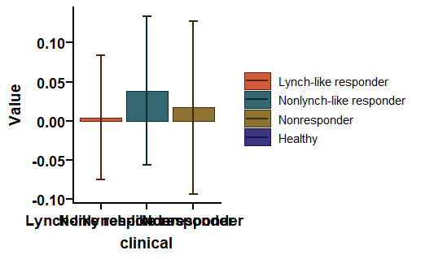

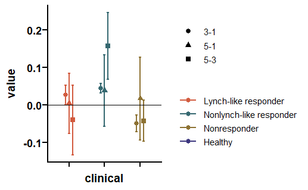

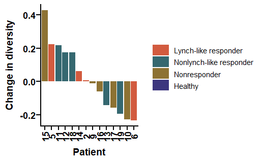

##### cell type diversity

this data is already log10(inv.simp)

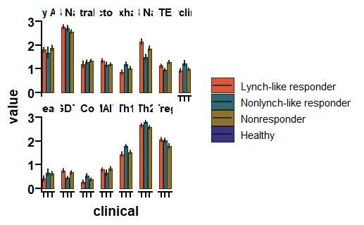

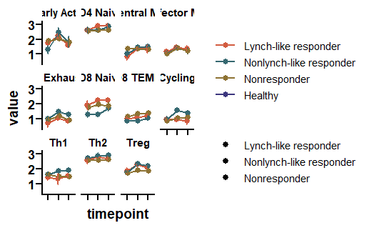

#### BM diversity

##### cell type diversity

this data is already log10(inv.simp)

#### rarefaction

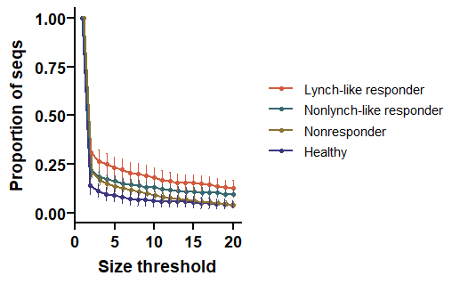

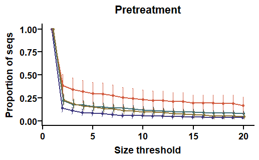

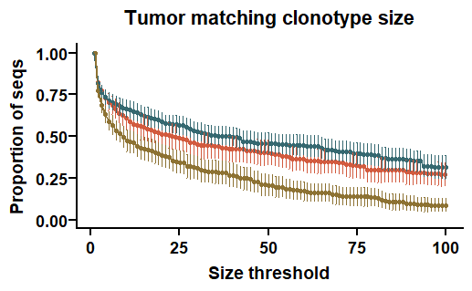

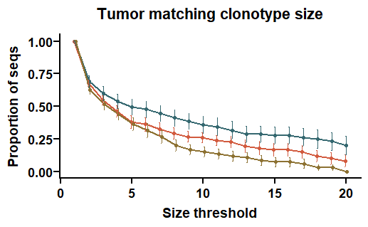

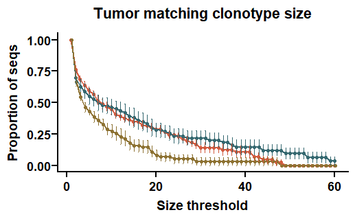

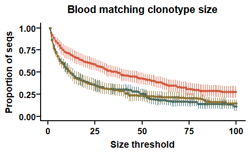

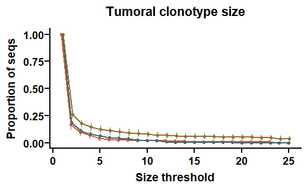

#### spectratyping

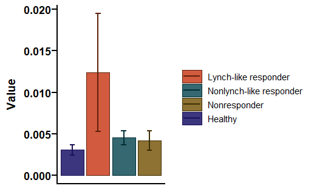

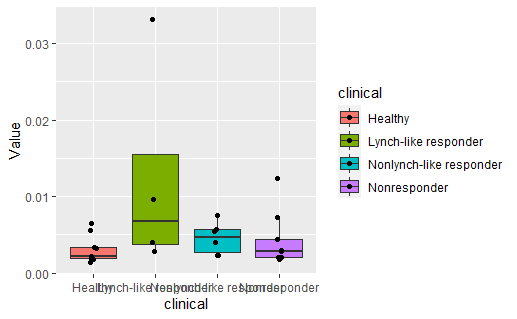

### overlap

#### similarity validation

the pre-post tils always strong cluster in overlap/jaccard/morisita 26/9/3/12 consistent, 19 and 7 iffy (7 really low counts)

morisita looks beautiful, all patients cluster really strongly some mixing with the low 20’s in jaccard and overlap, but overall very strong

overlap is nearly perfect (just 3til and 3pbmc separate but still have an island of overlap out there), jaccard good but mixes some up, morisita segregates like all the til from nontil

#### temporal pbmc overlap

yo jaccard ignores proportions/clones, just based off cdr3s

Not really any dramatic differences after filtering out the cell types with very few cells Tregs have very low overlap in general, Th2 as well, whereas CD8s have much higher

Once again, not really strong clinical diffs, maybe lynch higher CD8 act? (which is surprising) and nlr higher CD4 act? then again this is peripheral so not sure what to expect Treg has comparable temporal overlap to naive populations - less large preserved clones?

all really low counts, but CD8 Activated actually does look lower overlap in nlr though

#### pbmc-til overlap

looks like generally stronger 5-7 overlap (but small and not much for any other)

the questionable data shows enrichment towards both extremes with outliers removed though, it looks like just increase in TM overlap for NLR

it kinda looked like something was there, but looks inconclusive

#### Clonotype cell types

*this is erroring right now for me? 08.19* don’t have scaling worked out yet, and this is overall but treg lot of overlap cd4act cd8, cd8exh-act strong, cd4 act-exh?

not much clinical diff, maybe a bit more single in nr more 2+ in nr, more 2 in nlr/maybe l; the high nr outliers are 17

#### TEMRA distinctness

still not entirely sure about the mechanics of vegdist could still be a size effect of the temra, haven’t done downsampling also mean or median for the column version?

### Cell counts

#### Main

| type | clinical | patient | freq | prop |
| --- | --- | --- | --- | --- |
| CD4 Early Activated | Nonresponder | 1 | 260 | 0.0418881908 |
| CD4 Naive | Nonresponder | 1 | 1071 | 0.1725471242 |
| CD8 Central Memory | Nonresponder | 1 | 118 | 0.0190107943 |
| CD8 Effector Memory | Nonresponder | 1 | 635 | 0.1023038505 |
| CD8 Exhausted | Nonresponder | 1 | 52 | 0.0083776382 |
| CD8 Naive | Nonresponder | 1 | 172 | 0.0277106493 |
| CD8 TEMRA | Nonresponder | 1 | 1308 | 0.2107298212 |
| Cycling | Nonresponder | 1 | 91 | 0.0146608668 |
| Dead | Nonresponder | 1 | 46 | 0.0074109876 |
| GDT | Nonresponder | 1 | 160 | 0.0257773482 |

[output cut: 447 more lines]

[figure not shown]

got some interesting ones, 25 is just 14, 15 strong 23/5, 23-1 is just 6 cells, 21-1 is 200 cells specific clusts - 3 (l high - temra right),8 (nlr lo - cd8 naive), 12 (nlr hi, cd4 activated ish, center top), 16 (nlr hi - dead?), 18(nlr hi,l lo, cd4 naive),21 (nlr hi - cd4 early?), 24 (l lo,cd8-4 transition), 29 (l lo - left gdt), ldat clusts - 4(nlr lo-cd14mono),9(nlr hi-cd16 mono),19(l lo-cdc),21(nlr hi-cd16nk.2),22(l lo-cd56 nk),26(nlr hi-pdc),28(l lo,nlr hi-mono??),29(l hi-plasma),31(l lo-progenitor),32(l lo-b/mono)

hm, half of GDT have TCR ab sequences

[figure not shown]

[figure not shown]

[figure not shown]

That’s actually fire really clean for increase in nlr/nr exh/cycling, decrease/lower MAIT CD8 CM/Th2 increase to meet in lynch decreasing trend for all in TEM/TEMRA, increasing treg nlr low cd8 naive, increase th1

#### TM composition

[figure not shown]

#### Proportion TM

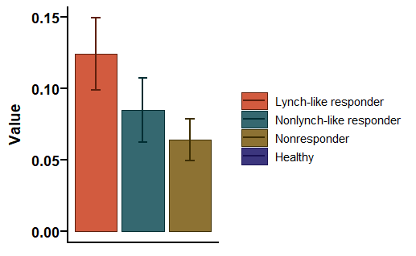

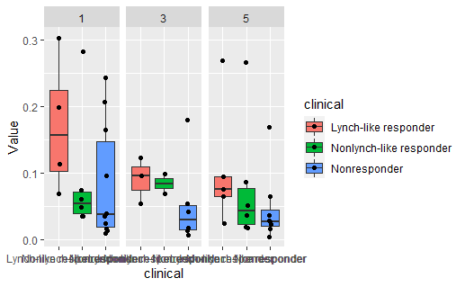

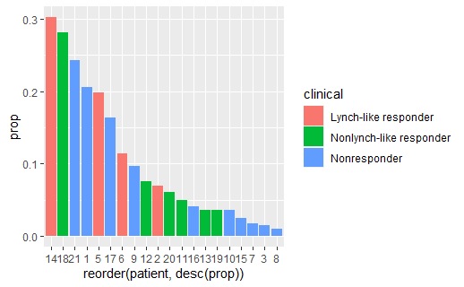

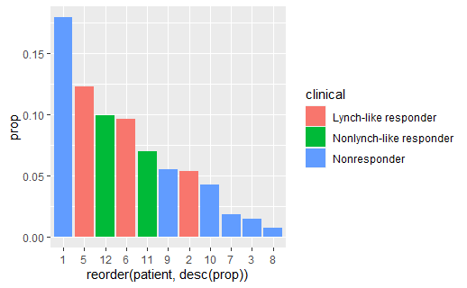

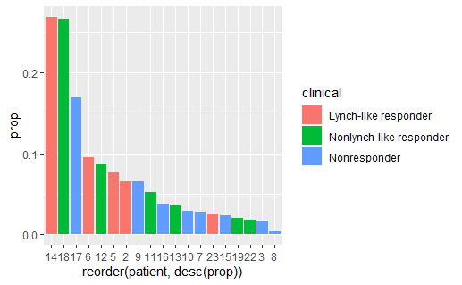

Lynch has higher prop of clones TM, decreases over time

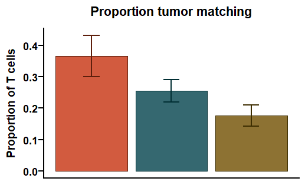

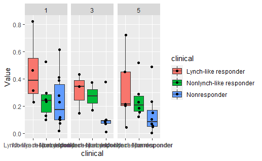

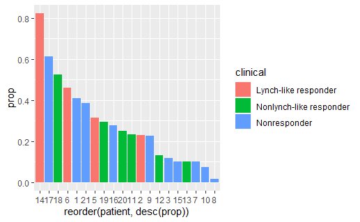

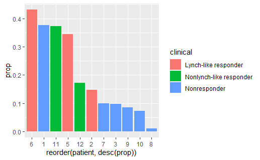

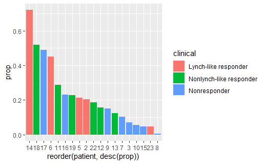

lynch highest prop TM, NLR second NLR is a lot more TM porpotion increase while others decrease But none of this translates to any pattern in change in TM clonality this could also be the result of sample size of pbmc and til - manual jaccard is better?

could do proportion of TMs for each by cell type or proportional composition of TMs for clinical by cell type and then uhhh raref TMs or actually that’s more div stuff

[figure not shown]

[figure not shown]

[figure not shown]

[figure not shown]

[figure not shown]

#### CD8 stuff

[figure not shown]

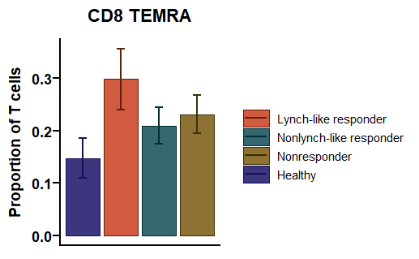

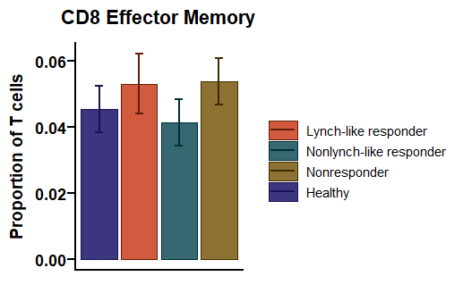

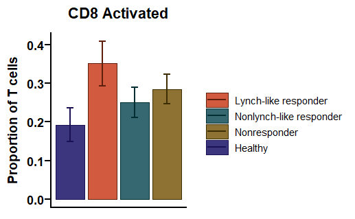

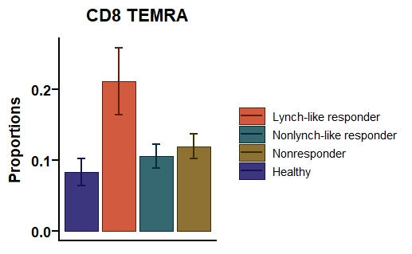

no real overall trends

### Misc

holy shit this is long